# Practical Machine Learning Course Project

Khanjan Damania

June 19, 2016

## Backgound and Introduction

Using devices such as Jawbone Up, Nike FuelBand, and Fitbit it is now possible to collect a large amount of data about personal activity relatively inexpensively. These type of devices are part of the quantified self-movement - a group of enthusiasts who take measurements about themselves regularly to improve their health, to find patterns in their behavior, or because they are tech geeks. One thing that people regularly do is quantify how much of a particular activity they do, but they rarely quantify how well they do it. In this project, we will use data recorded from accelerometers on the belt, forearm, arm, and dumbbell of 6 participants. They were asked to perform barbell lifts correctly and incorrectly in 5 different ways. More information is available from the website http://groupware.les.inf.puc-rio.br/har (see the section on the Weight Lifting Exercise Dataset).

The goal of this project is to predict the manner in which the participants did the exercise. This is the classe variable of the training set, which classifies the correct and incorrect outcomes into A, B, C, D, and E categories. This report describes how the model for the project was built, its cross validation, expected out of sample error calculation, and the choices made. It was used successfully to accurately predict all 20 different test cases on the Coursera website.

This document is the write-up submission for the course Practical Machine Learning. This 4-week course was offered on Coursera in June 2016, and is part of Johns Hopkins Data Science Specialization.

## Data Description

The training data for this project are available here: https://d396qusza40orc.cloudfront.net/predmachlearn/pml-training.csv

The test data are available here: https://d396qusza40orc.cloudfront.net/predmachlearn/pml-testing.csv

The data for this project come from this source: http://groupware.les.inf.puc-rio.br/har. If you use the document you create for this class for any purpose please cite them as they have been very generous in allowing their data to be used for this kind of assignment.

## Libraries Used

The following libraries were used for this project, which should be installed and loaded on the working environment.

```r
library(caret)
```

```r
library(rpart)
library(rpart.plot)
library(RColorBrewer)
library(rattle)
library(randomForest)
```

Set the seed

```r
set.seed(12345)
```

## Data Gathering

Load in the training dataset from the link into trainingData variable

```r
trainingData <- read.csv(url("http://d396qusza40orc.cloudfront.net/predmachlearn/pml-training.csv"), na.strings=c("NA","#DIV/0!",""))
```

Load in the testing dataset from the link into testingData variable

```r
testingData <- read.csv(url("http://d396qusza40orc.cloudfront.net/predmachlearn/pml-testing.csv"), na.strings=c("NA","#DIV/0!",""))
```

## Data Cleaning

```r
trainingData <- trainingData[, 6:dim(trainingData)[2]]
threshold <- dim(trainingData)[1] * 0.95
```

Remove columns with more than 95% of NA or “” values

```r
goodColumns <- !apply(trainingData, 2, function(x) sum(is.na(x)) > threshold  || sum(x=="") > threshold)
trainingData <- trainingData[, goodColumns]
badColumns <- nearZeroVar(trainingData, saveMetrics = TRUE)
trainingData <- trainingData[, badColumns$nzv==FALSE]
trainingData$classe = factor(trainingData$classe)
```

## Data Partitioning

Partioning Training data set into two data sets, 70% for dataTraining, 30% for dataValidating:

```r
inTraining <- createDataPartition(y=trainingData$classe, p=0.70, list=FALSE)
dataTraining <- trainingData[inTraining, ]; dataValidating <- trainingData[-inTraining, ]
dim(dataTraining); dim(dataValidating)
```

```
## [1] 13737    54
```

```
## [1] 5885   54
```

## ML Algorithm 1: Decision Tree

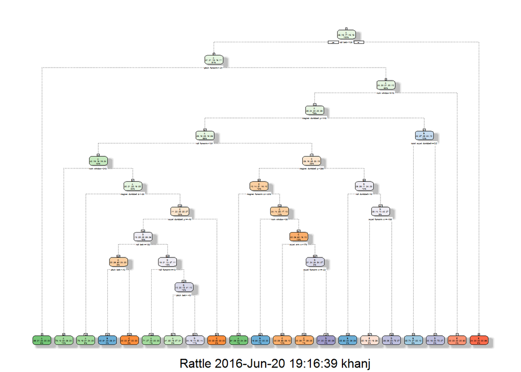

```r
modelFitA1 <- rpart(classe ~ ., data=dataTraining, method="class")
fancyRpartPlot(modelFitA1)
```

```r
predictionsA1 <- predict(modelFitA1, dataValidating, type = "class")
confusionMatrix(predictionsA1, dataValidating$classe)
```

```
## Confusion Matrix and Statistics
##
##           Reference
## Prediction    A    B    C    D    E
##          A 1530  269   51   79   16
##          B   35  575   31   25   68
##          C   17   73  743   68   84
##          D   39  146  130  702  128
##          E   53   76   71   90  786
##
## Overall Statistics
##
##                Accuracy : 0.7368
##                  95% CI : (0.7253, 0.748)
##     No Information Rate : 0.2845
##     P-Value [Acc > NIR] : < 2.2e-16
##
##                   Kappa : 0.6656
##  Mcnemar's Test P-Value : < 2.2e-16
##
## Statistics by Class:
##
##                      Class: A Class: B Class: C Class: D Class: E
## Sensitivity            0.9140  0.50483   0.7242   0.7282   0.7264
## Specificity            0.9014  0.96650   0.9502   0.9100   0.9396
## Pos Pred Value         0.7866  0.78338   0.7543   0.6131   0.7305
## Neg Pred Value         0.9635  0.89051   0.9422   0.9447   0.9384
## Prevalence             0.2845  0.19354   0.1743   0.1638   0.1839
## Detection Rate         0.2600  0.09771   0.1263   0.1193   0.1336
## Detection Prevalence   0.3305  0.12472   0.1674   0.1946   0.1828
## Balanced Accuracy      0.9077  0.73566   0.8372   0.8191   0.8330
```

The Decision Tree algorithm predicts with our validating dataset with an accuracy of 73.68% and Kappa value of 0.6656

## ML Algorithm 2: Random Forests

```r
modelFitB1 <- randomForest(classe ~. , data=dataTraining)
predictionsB1 <- predict(modelFitB1, dataValidating, type = "class")
confusionMatrix(predictionsB1, dataValidating$classe)
```

```
## Confusion Matrix and Statistics
##
##           Reference
## Prediction    A    B    C    D    E
##          A 1674    5    0    0    0
##          B    0 1133    8    0    0
##          C    0    1 1018   12    0
##          D    0    0    0  952    4
##          E    0    0    0    0 1078
##
## Overall Statistics
##
##                Accuracy : 0.9949
##                  95% CI : (0.9927, 0.9966)
##     No Information Rate : 0.2845
##     P-Value [Acc > NIR] : < 2.2e-16
##
##                   Kappa : 0.9936
##  Mcnemar's Test P-Value : NA
##
## Statistics by Class:
##
##                      Class: A Class: B Class: C Class: D Class: E
## Sensitivity            1.0000   0.9947   0.9922   0.9876   0.9963
## Specificity            0.9988   0.9983   0.9973   0.9992   1.0000
## Pos Pred Value         0.9970   0.9930   0.9874   0.9958   1.0000
## Neg Pred Value         1.0000   0.9987   0.9984   0.9976   0.9992
## Prevalence             0.2845   0.1935   0.1743   0.1638   0.1839
## Detection Rate         0.2845   0.1925   0.1730   0.1618   0.1832
## Detection Prevalence   0.2853   0.1939   0.1752   0.1624   0.1832
## Balanced Accuracy      0.9994   0.9965   0.9948   0.9934   0.9982
```

```r
OOS_err_rate = sum(predictionsB1 != dataValidating$classe)/length(dataValidating$classe)
OOS_err_rate
```

```
## [1] 0.005097706
```

The Confusion Matrix for Random Forests algorithm achieved 99.49% accuracy and an out-of-sample error rate of 0.51%. This model will be used for the final calculations.

## Prediction on the Testing dataset

```r
predictionsB2 <- predict(modelFitB1, testingData, type = "class")
```

## Conclusion

In this project, two machine learning algorithms were built using 54 variables (less than one-third of the covariates). Decision Tree predicted with an accuracy of 73.68% and Random Forests predicted with an almost perfect accuracy of 99.49%.

## Generating answers for Course Project Prediction Quiz

```r
pml_write_files = function(x){
  n = length(x)
  for(i in 1:n){
    filename = paste0("problem_id_",i,".txt")
    write.table(x[i],file=filename,quote=FALSE,row.names=FALSE,col.names=FALSE)
  }
}
pml_write_files(predictionsB2)
```

(The prediction result pred.char is not displayed intentionally due to Honour Code, because it is the answer of the “project submission” part.)